# Figure 3 and supplementary figure 3

Author

Niccolò Arecco & Ivano Mocavini

Last code execution: 2024 January 24, Wednesday @ 19:01:20.

# 1 Intro

Here there is the code for plotting the gradient fractionation Western blots quantifications and the ColabFold PRC2 structural predictions analysis.

The SUZ12 dimer-disrupting triple mutation “3D” (K195D, R196D, K197D) was first described here (Chen et al. 2020). The interaction between SUZ12-C2 and RBBP4 acidic pocket is reviewed in details here(Chammas, Mocavini, and Di Croce 2020).

**Figure size**

Here I display the plots with the same size that they’ll have in the final Adobe Illustrator file. If you want to see them big, zoom in in your browser or open the pdf figures on GitHub.

# 2 Set Up

To fetch the pdb files stored on the CRG cluster I mount the server on my local computer with the following command in the terminal.

```bash
sshfs narecco@ant-login.linux.crg.es:/users/mirimia ~/mnt
```

## 2.1 Packages

```r
library(readxl)
library(dplyr, warn.conflicts = F, quietly = T)
library(tidyr)
library(tibble)
library(stringr)
library(rstatix)
library(ggplot2)
library(ggbeeswarm)
library(ggsignif)
library(viridis)
library(Cairo)
```

The package `extrafont` is require for the ‘cdot’ symbol (`%.%`) to be shown when displaying *P*-values.

```r
library(extrafont)
# extrafont::font_import() # do it only once
loadfonts(quiet = T)
```

To efficiently read in R pdb files I use the function `bio3d::read.pdb()`, that I installed without all its dependencies.

```r
# install.packages("bio3d", dependencies = FALSE)
library(bio3d)
```

## 2.2 Functions

Define plots style.

```r
theme_bw(base_family = 'Arial', base_size = 6) +
  theme(axis.line = element_line(colour = "black", linewidth = 0.1),
        axis.text = element_text(colour = "black"),
        axis.text.x = element_text(margin = margin(t = 0)),
        axis.text.y = element_text(margin = margin(r = 0)),
        axis.title = element_text(size = 5),
        axis.title.x = element_text(vjust = 0, margin = margin(t = 0, unit = 'mm')),
        axis.title.y = element_text(vjust = 1, margin = margin(r = 0, unit = 'mm')),
        axis.ticks = element_line(colour = "black", linewidth = 0.1),
        axis.ticks.length = unit(1, units = "mm"),
        legend.title = element_blank(),
        legend.text = element_text(margin = margin(t = 0, b = 0, unit = 'mm')),
        legend.position = c(0.89, 0.96),
        legend.spacing = unit(x = 0.1, units = 'mm'),
        legend.key.size = unit(x = 0.1, units = 'mm'),
        legend.background = element_rect(fill = "white", linewidth = 0, colour = NA),
        legend.margin = margin(t = 0, b = 0, l = 0, r = 0, unit = 'mm' ),
        panel.grid.major = element_line(colour = "grey84", linewidth = 0.1),
        panel.grid.minor = element_blank(),
        panel.background = element_blank(),
        panel.border = element_blank(),
        panel.spacing.y = unit(x = 1.5, units = 'mm'),
        strip.background = element_blank(),
        strip.text.y = element_text(vjust = 0, hjust = 0.5, margin = margin(l = 0, unit = 'mm')),
        plot.background = element_blank(),
        plot.margin = margin(t = 0, b = 0, l = 0, r = 0, unit = 'mm')
        ) -> gradients_theme

theme_classic(base_family = 'Arial', base_size = 5) +
  theme(axis.text = element_text(colour = 'black'),
        axis.text.x = element_text(vjust = 3),
        axis.title.x = element_blank(),
        axis.title.y = element_text(size = 4),
        axis.ticks.length = unit(1, 'mm'),
        axis.ticks = element_line(linewidth = 0.1, colour = 'black'),
        axis.ticks.x = element_blank(),
        axis.line = element_line(linewidth = 0.1, colour = 'black'),
        panel.grid.major.y = element_line(linewidth = 0.2, colour = 'gray84'),
        panel.background = element_blank(),
        strip.background = element_blank(),
        strip.text = element_text(hjust = 0.5, size = 6),
        plot.background = element_blank() ) -> colabfold_distances_theme
```

Helper functions for the analysis of ColabFold predictions.

- Calculate the euclidean distance.

```r
euclidean_dist3D <- function(P1, P2) {

  # Assuming 2 points in a 3D space with coordinates:
  # P1 <- c('x' = 29.187, 'y' = 76.150, 'z' = 54.973)
  # P2 <- c('x' = 10.493, 'y' = -37.222, 'z' = -4.964)

  # This functions applies the euclidean distance as:
  # distP1P2 <- sqrt( (P2['x'] - P1['x'])^2 + (P2['y'] - P1['y'])^2 +  (P2['z'] - P1['z'])^2 )
  distP1P2 <- sqrt(sum((P2 - P1)^2))
  return(distP1P2)
}
```

- Given a pdb file extract the coordinates of a certain atom to dataframe. If `annotate = TRUE` returns a df with info. If `FALSE` only coordinates.

```r
pdb2coord_df <- function(pdb, chain_letter, residue_num, atom_type = 'CA', annotate = TRUE) {
  pdb$atom |>
    subset(resno %in% residue_num & elety %in% atom_type & chain %in% chain_letter) |>
    as_tibble() |>
    column_to_rownames('resno') |>
    select(c('x', 'y', 'z')) |>
    as.data.frame() -> residue_coord_df

  stopifnot(all(rownames(residue_coord_df) %in% residue_num))

  if ( annotate == TRUE ) {
    residue_coord_df |>
      rownames_to_column('resno') |>
      mutate(chain = chain_letter,
             atom_type = atom_type) |>
      relocate(x, y, z, .after = atom_type) |>
      relocate(resno, .after = chain )-> residue_coord_df
  }
  return(residue_coord_df)
}
```

- Given a pdb dataframe calculate the distance between all atoms in the rows of the pdb.

This doesn’t work if there’s another column like the `model_ranking`. If working only on one pdf file in one dataframe and specifying the residues use: `calculate_residues_interdistances(aa_res_pos = residue_num_vector)`

```r
calculate_residues_interdistances <- function(pdb_df, aa_res_pos ) {

  cols_to_keep <- c('x', 'y', 'z', 'resno')
  pdb_df |>
    select(all_of(cols_to_keep)) |>
    rowwise() |>
    mutate(xyz = list(c(x, y, z) )) |>
    select(resno, xyz) -> coord_df

  pdb_self_dist <- data.frame()
  # Nested for loop to calculate distances
  for (i in 1:nrow(coord_df)) {
    for (k in 1:nrow(coord_df)) {
      # message('P', i, ' P', k, ': ', euclidean_dist3D(P1 = unlist(coord_df[i,]$xyz), P2 = unlist(coord_df[k,]$xyz)))
      pdb_self_dist[i, k] <- euclidean_dist3D(P1 = unlist(coord_df[i,]$xyz), P2 = unlist(coord_df[k,]$xyz))
    }
  }
  # head(pdb_self_dist)
  # Set to zero lower matrix triangle (of sadness) to be removed later as matrix is specular
  pdb_self_dist[lower.tri(pdb_self_dist)] <- 0
  rownames(pdb_self_dist) <- aa_res_pos
  colnames(pdb_self_dist) <- aa_res_pos

  # reshape into a tidy long dataframe
  pdb_self_dist |>
    rownames_to_column('from_resno') |>
    pivot_longer(cols = !c('from_resno'), names_to = 'to_resno', values_to = 'dist') |>
    mutate(to_resno = as.integer(gsub('V', '', to_resno)) ) |>
    mutate(from_resno = as.integer(from_resno) ) |>
    mutate(from_resno = factor(from_resno, levels = RBBP4_residue_num)) |>
    mutate(to_resno = factor(to_resno, levels = RBBP4_residue_num)) |>
    subset(from_resno != to_resno) |>
    subset(dist > 0) -> tidy_pdb_dist
  return(tidy_pdb_dist)
}
```

- Given a `pdb_df` with residue number (`resno`), and an atom of such residue `x`, `y`, and `z` coordinates (in 3 different columns) calculate all residues pairs (all-vs-all) euclidean distances if passing a grouped `pdb_df` (made with `group_by`, like `model_rank` for example), this is preserved. If working on more than one pdb (specify the ID with `group_by()` ) and calculate it for all residues.

```r
calculate_residues_pairs_distances <- function(pdb_df) {
  cols_to_keep <- c('x', 'y', 'z', 'resno')
  pdb_df |>
    select(all_of(cols_to_keep)) |>
    rowwise() |>
    mutate(xyz = list(c(x, y, z) )) |>
    # remove individual coordinates
    select(!c(x, y, z)) |>
    ungroup() -> coord_df

  # create a to_resno aa-pair dataframe
  coord_df |>
    select(resno) |>
    unique() |>
    # expand the resno making a AA pair to residue number
    expand_grid(to_resno = resno) |>
    # join back with the coord_df
    left_join(y = coord_df, by = join_by(resno)) -> aa_pairs

  # create a to_resno coordinate dataframe to add
  to_coord_df <- coord_df
  colnames(to_coord_df)[colnames(to_coord_df) == 'resno'] <- 'to_resno'
  colnames(to_coord_df)[colnames(to_coord_df) == 'xyz'] <- 'to_xyz'

  # add to_coordiante and calculate distance
  aa_pairs |>
    left_join(y = to_coord_df, by = join_by(to_resno) ) |>
    rowwise() |>
    mutate(dist = euclidean_dist3D(P1 = xyz, P2 = to_xyz)) |>
    relocate(resno, to_resno, .before = xyz) |>
    ungroup() -> aa_pairs_dist_df
  return(aa_pairs_dist_df)
}
```

## 2.3 Directories & File Paths

Here I organise all the variables I need to run the analysis and define where to save the processed tables and figures.

```r
oneDrive_Dir <- file.path("~/OneDrive - CRG - Centre de Regulacio Genomica/Suz12_AS_project")
code_dir_fig3 <- file.path(oneDrive_Dir, "_Code/Fig3")
tbl_dir_fig3 <- file.path(code_dir_fig3, "tables")
pdf_dir_fig3 <- file.path(code_dir_fig3, "pdfs")

if (!dir.exists(pdf_dir_fig3)) { dir.create(pdf_dir_fig3, recursive = T) }
if (!dir.exists(tbl_dir_fig3)) { dir.create(tbl_dir_fig3, recursive = T) }
```

All WB quantifications are stored in differet sheets in one excel file

```r
wb_quant_path <- list.files(tbl_dir_fig3,
                            pattern = "^Gradient_WB_quantifications.xlsx$",
                            full.names = T)
stopifnot(file.exists(wb_quant_path))
```

All ColabFold pdb predictions are stored in the cluster

```r
proj_dir <- file.path('~/mnt/narecco/projects/12_Predicted_Structures')
cf_pdb <- file.path(proj_dir, 'data/pdb/CF')
PRC2_ex4_inclusion_dir <- file.path(cf_pdb, 'PRC2_ex4_inclusion')
PRC2_ex4_exclusion_dir <- file.path(cf_pdb, 'PRC2_ex4_exclusion')

if (!dir.exists(PRC2_ex4_inclusion_dir)) {
  stop("I can't find the folder with the pdb files predictions for the inclusion isoform!")
  stop('Check that this folderpath actually exists:\n', PRC2_ex4_inclusion_dir)
}

if (!dir.exists(PRC2_ex4_exclusion_dir)) {
  stop("I can't find the folder with the pdb files predictions for the exclusion isoform!")
  stop('Check that this folderpath actually exists:\n', PRC2_ex4_exclusion_dir)
}
```

# 3 Main Figure Panels

The quantification where done beforehand using the raw tiff files and measuring the area under the bands.

## 3.1 Gradient fractionation WB quantification plot

### 3.1.1 WT and ∆ex4 samples: PRC2.1 & PRC2.2 proteins

This analysis plots the quantification from the first biological replicates pair.

```r
wt <- read_excel(path = wb_quant_path, sheet = "WT_1")
ex4 <- read_excel(path = wb_quant_path, sheet = "dEX4_1")
rescues <- read_excel(path = wb_quant_path, sheet = 'Rescues')
```

Normalise all fractions to the maximal fraction intensity. Here each fraction is an individual Western blot gel lane.

```r
wt[,2:ncol(wt)] <- apply(wt[,2:ncol(wt)],2,function(x){x/max(x)})
wt$line <- "WT"

ex4[,2:ncol(ex4)] <- apply(ex4[,2:ncol(ex4)],2,function(x){x/max(x)})
ex4$line <- "∆ex4"

rescues[,2:ncol(rescues)] <- apply(rescues[,2:ncol(rescues)],2,function(x){x/max(x)})
```

Combine quantifications of WT and ∆ex4 and reshape the data for plotting.

```r
rbind(wt, ex4) |>
  pivot_longer(cols = !c("Fraction", "line"), names_to = "Protein", values_to = "Intensity") |>
  mutate(line = factor(line, levels = c("WT", "∆ex4"))) -> fractionation_wb
rm(wt, ex4)
```

Set protein order.

```r
fractionation_wb$Protein <- factor(fractionation_wb$Protein,
                                   levels = c("SUZ12", "EZH2", "EPOP", "MTF2", "JARID2", "AEBP2"))
fractionation_wb$BiolRep <- 1
```

Plot figure 3C.

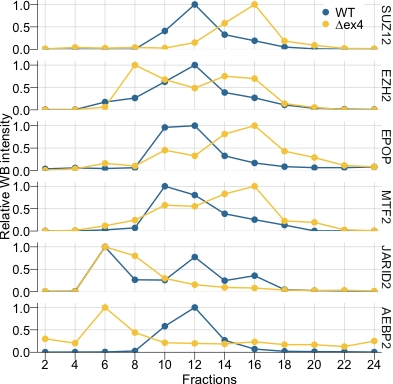

```r
ggplot(data = fractionation_wb) +
  aes(x = Fraction, y = Intensity, color = line) +
  facet_grid(rows = vars(Protein) ) +
  geom_line(linewidth = 0.25, linetype = 'solid') +
  geom_point(aes(fill = line), size = 0.5, shape = 21, stroke = 0.5) +
  scale_x_continuous(breaks = seq(2, 24, 2), limits = c(2, 24),
                     expand = expansion(add = 0.5, mult = 0) ) +
  scale_y_continuous(breaks = c(0, 0.5, 1), expand = expansion(add = c(0, 0.1), mult = 0) ) +
  scale_color_manual(values = c('WT' = "#377AA3", '∆ex4' = "#F7CB48") ) +
  scale_fill_manual(values = c('WT' = "#377AA3", '∆ex4' = "#F7CB48") ) +
  coord_cartesian(ylim = c(0, 1)) +
  labs(x = 'Fractions', y = 'Relative WB intensity') +
  gradients_theme -> p_wt_dex_frac_wb
p_wt_dex_frac_wb
```

Save to pdf.

```r
ggsave(filename = "Fig3C_Gradient_WT_Dex4_Line.pdf", path = pdf_dir_fig3,
       plot = p_wt_dex_frac_wb, device = cairo_pdf, units = 'cm',
       width = 5.15, height = 5)
```

Make also a smaller figure removing the very first and last fractions, a zoom-in version

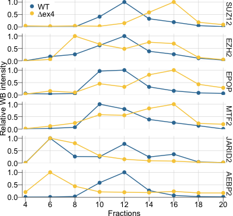

```r
p_wt_dex_frac_wb +
  scale_x_continuous(breaks = seq(2, 24, 2), limits = c(4, 20),
                     expand = expansion(add = 0.25, mult = 0) ) +
  theme(legend.position = c(0.10, 0.96)) -> p_wt_dex_frac_zoom
p_wt_dex_frac_zoom
```

Save to pdf

```r
ggsave(filename = "Fig3C_Gradient_WT_Dex4_ZOOMED_Line.pdf", path = pdf_dir_fig3,
       plot = p_wt_dex_frac_zoom, device = cairo_pdf, units = 'cm',
       width = 5.0, height = 5)
```

### 3.1.2 KO rescue samples: flag-tagged SUZ12

Plot rescues.

```r
rescues |>
  pivot_longer(cols = !c("Fraction"), names_to = "Rescue", values_to = "Intensity") |>
  mutate(SUZ12_Isoform = str_split_fixed(string = Rescue, pattern = "_", n = 2)[,1] )  |>
  mutate(Replicate = as.integer(str_split_fixed(string = Rescue, pattern = "_", n = 2)[,2]) ) |>
  mutate(Protein = case_when(SUZ12_Isoform == 'Long' ~ 'SUZ12-L',
                             SUZ12_Isoform == 'Short' ~ 'SUZ12-S',
                             SUZ12_Isoform == 'L3D' ~ 'SUZ12-L3D',
                             SUZ12_Isoform == 'S3D' ~ 'SUZ12-S3D') ) |>
  mutate(Protein = factor(Protein, levels = c('SUZ12-L', 'SUZ12-S', 'SUZ12-L3D', 'SUZ12-S3D') ) ) |>
  mutate(lineName = case_when(SUZ12_Isoform == 'Long' ~ 'KO+L',
                              SUZ12_Isoform == 'Short' ~ 'KO+S',
                              SUZ12_Isoform == 'L3D' ~ 'KO+L3D',
                              SUZ12_Isoform == 'S3D' ~ 'KO+S3D') ) |>
  mutate(line = paste0(lineName, " #", Replicate ) ) |>
  mutate(line = factor(line, levels = c("KO+L #1", "KO+L #2",
                                        "KO+S #1", "KO+S #2",
                                        "KO+L3D #1", "KO+L3D #2", "KO+L3D #3",
                                        "KO+S3D #1", "KO+S3D #2")
                       ) ) -> fractionation_wb_rescues
```

Set colours

```r
rescue_palette <- c("KO+L #1" = "#7b67ab", "KO+L #2" = "#A092CC",
                    "KO+S #1" = "#f07e19", "KO+S #2" = "#EFAB78",
                    "KO+L3D #1" = "#74A57F", "KO+L3D #2" = "#7FC78F", "KO+L3D #3" = "#A0E0AC",
                    "KO+S3D #1" = "#E8B4BC", "KO+S3D #2" = "#F0D1D5" )
```

Plot rescues

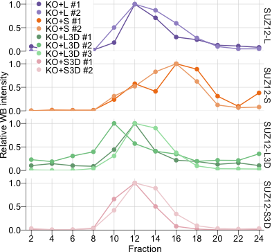

```r
ggplot(data = fractionation_wb_rescues) +
  aes(x = Fraction, y = Intensity, color = line) +
  facet_grid(rows = vars(Protein) ) +
  geom_line(linewidth = 0.25, linetype = 'solid') +
  geom_point(aes(fill = line), size = 0.5, shape = 21, stroke = 0.5) +
  labs(y = "Relative WB intensity")+
  scale_x_continuous(breaks = seq(2, 24, 2), limits = c(2, 24), expand = expansion(add = 0.5, mult = 0) ) +
  scale_y_continuous(breaks = c(0, 0.5, 1), expand = expansion(add = c(0, 0.1), mult = 0) ) +
  scale_color_manual(values = rescue_palette ) +
  scale_fill_manual(values = rescue_palette ) +
  coord_cartesian(ylim = c(0, 1)) +
  theme_classic(base_size = 6, base_family = "Arial") +
  gradients_theme +
  theme(legend.position = c(0.165, 0.85) ) -> p_rescue_frac_wb
p_rescue_frac_wb
```

Save the pdf.

```r
ggsave(filename = "Fig3E_Gradient_Rescues_Line.pdf", plot = p_rescue_frac_wb,
       path = pdf_dir_fig3, device = cairo_pdf, units = 'cm',
       width = 5.0, height = 5.65)
```

## 3.2 ColabFold Predictions

I used colabfold (Mirdita et al. 2022) to predict 5 different models of PRC2 with and without SUZ12 exon 4. The code I used to generate the predictions can be found at [my GitHub repository](https://github.com/Ni-Ar/colabfold_crg).

Here I parse the pdb files with the PRC2 structure predictions and calculate the distance between the positively charged C2 domain arginine 196 (similar results also observed when considering SUZ12-L: 195-197) and the negatively charged RBBP4 residue (RBBP4: 126, 128, 179, 181, 231, 248, 275, 277, 319). These residues were selected as reviewed here (Chammas, Mocavini, and Di Croce 2020) in figure 2C.

```r
# SUZ12_residue_num <- c(195:197)
SUZ12_residue_num <- c(196)
RBBP4_residue_num <- c(126, 128, 179, 181, 231, 248, 275, 277, 319)
```

Use a for loop to calculate the distances between all 5 different pdf files. The following code performes the following steps:

1. Import both inclusion and exclusion pdb files.
2. Extract the coordinates of Arg196 (taking into account the missing 23 amino acids in SUZ12-S) and the acidic patch of RBBP4
3. Calculate Euclidean distance between all amino acids pairs.
4. Combines the distances between the inclusion and exclusion proteoforms.
5. Performes a two-sided, paired, Wilcoxon rank rum significance test (`wilcox_test`) between the residue distances distributions in each pdb file and calculate Cohen’s effect size d (`cohens_d`).
6. Plots the distances as boxplots for each prediction and saves it to a pdf file.
7. Populates 2 list with the results for the distances and *P*-values.
8. Cleans up and restart the loop.

```r
pdb_rank <- c(1:5)
list_df <- list()
list_p_anno <- list()
for (p in 1:length(pdb_rank)) {

  # -- 1 -- Import each PRB by rank order ----
  inc_rnk_path <- list.files(PRC2_ex4_inclusion_dir,
                             pattern = paste0("_relaxed_rank_00", pdb_rank[p], "_"),
                             full.names = T)

  exc_rnk_path <- list.files(PRC2_ex4_exclusion_dir,
                             pattern = paste0("_relaxed_rank_00", pdb_rank[p], "_"),
                             full.names = T)
  # Import PDBs in R
  pdb_inc <- read.pdb(file = inc_rnk_path)
  pdb_exc <- read.pdb(file = exc_rnk_path)

  # -- 2 -- Extract coordinates  ----
  ## extract PDB coordinates of SUZ12 Arg196 region Calpha coordinate
  group1_coord_inc <- pdb2coord_df(pdb = pdb_inc, chain_letter = 'B',
                                   residue_num = SUZ12_residue_num,
                                   atom_type = 'CA')

  # extract PDB coordinates of Arg 196 -23 exon for the SUZ12-S
  group1_coord_exc <- pdb2coord_df(pdb = pdb_exc, chain_letter = 'B',
                                   residue_num = SUZ12_residue_num - 23,
                                   atom_type = 'CA')

  ## extract PDB coordinates of the ACIDIC hole of RBBP4
  # inclusion PDB
  group2_coord_inc <- pdb2coord_df(pdb = pdb_inc,
                                   residue_num = RBBP4_residue_num,
                                   chain_letter = 'D', atom_type = 'CA')

  # exclusion PDB
  group2_coord_exc <- pdb2coord_df(pdb = pdb_exc,
                                   residue_num = RBBP4_residue_num,
                                   chain_letter = 'D', atom_type = 'CA')

  stopifnot(nrow(group2_coord_inc) == nrow(group2_coord_exc))

  coord_inc <- rbind(group1_coord_inc, group2_coord_inc)
  coord_exc <- rbind(group1_coord_exc, group2_coord_exc)

  # -- 3 -- Calculate euclidean distance  ----
  coord_inc |>
    calculate_residues_pairs_distances() |>
    left_join(coord_inc, by = join_by(resno) ) |>
    select( !c(x, y, z) )|>
    # subset( resno != to_resno ) |>
    mutate(structure = 'SUZ12-L') -> dist_inc

  coord_exc |>
    calculate_residues_pairs_distances() |>
    left_join(coord_exc, by = join_by(resno) ) |>
    select( !c(x, y, z) )|>
    # subset( resno != to_resno ) |>
    mutate(structure = 'SUZ12-S') -> dist_exc

  # -- 4 -- Merge inclusion and exclusion data ----
  dist_df <- rbind(dist_inc, dist_exc) |>
    # add model
    mutate(model_rank = pdb_rank[p] ) |>
    # coerc to interger residue numbers
    mutate(resno = as.integer(resno),
           to_resno = as.integer(to_resno)) |>
    # remove self-distance
    subset(resno != to_resno) |>
    # remove coordiantes
    select(!c(xyz, to_xyz) ) |>
    # from residue is in SUZ12
    subset(resno %in% c(SUZ12_residue_num - 23, SUZ12_residue_num) ) |>
    # to residue is not in SUZ12
    subset(!to_resno %in% c(SUZ12_residue_num - 23, SUZ12_residue_num) ) |>
    # Add residue distance pair column
    mutate(AA_pair = case_when(structure == 'SUZ12-L' ~ paste0(resno, "-", to_resno),
                               structure == 'SUZ12-S' ~ paste0(resno + 23, "-", to_resno) ) ) # add 23 to the short to create a matching pair

  # -- 5 -- Significance test ----
  # Calculate p-values and format them for a figure in ggplot
  dist_df |>
    wilcox_test(dist ~ structure, ref.group = "SUZ12-L",
                alternative = 'two.sided', p.adjust.method = 'none', paired = T ) |>
    mutate(p = signif(p, 1)) |>
    mutate(p_signif = case_when(p < 2.2e-16 ~ paste0("list(~italic(p)", "<2.2%.%10^-16", ")" ),
                                between(p, left = 2.2e-16, right = 0.05) ~ paste0("list(~italic(p)==", p, ")" ),
                                p >= 0.05 ~ 'list(~italic(N.S.))') ) |>
    mutate(p_signif = gsub("e-", "%.%10^", p_signif)) |>
    select(group1, group2, n1, n2, p, p_signif) -> p_anno_df

  # # and effect size
  dist_df |>
    cohens_d(dist ~ structure, var.equal = T, ref.group = "SUZ12-L", paired = T) |>
    select(group1, group2, effsize, magnitude) |>
    mutate(effsize =  paste0("list(~d==", signif(effsize, 2) ,")") ) |>
    left_join(x = p_anno_df, by = c("group1", "group2") ) |>
    mutate(signig_label = paste0( gsub(")$", "", p_signif), gsub("^list\\(", "", effsize) ) ) |>
    relocate(signig_label, .after = group2) -> p_anno_df
  p_anno_df$model_rank <- pdb_rank[p]

  # -- 6 -- Plot ----
  ggplot(dist_df) +
    aes(x = structure, y = dist, fill = structure) +
    geom_boxplot(show.legend = F, linewidth = 0.15, outlier.shape = NA) +
    geom_point(size = 0.5, show.legend = F, position = position_quasirandom(width = 0.05)) +
    geom_line( aes(group = AA_pair), linewidth = 0.15, colour = 'blue', linetype = 'dashed') +
    scale_fill_manual(values = c('SUZ12-S' = '#f07e19', 'SUZ12-L' = '#7b67ab')) +
    geom_signif(comparisons = list( c("SUZ12-L", "SUZ12-S")),
                parse = T, annotations = p_anno_df$signig_label,
                textsize = 2, family = "Arial", lwd = 0.2, vjust = 0.2,
                tip_length = 0.02)  +
    scale_y_continuous(limits = c(0, NA),
                       expand = expansion(add = c(0, 2), mult = 0),
                       n.breaks = 8) +
    labs(title = paste0('CF pdb rank #', pdb_rank[p]),
         y = "Distance SUZ12 R196 to RBBP4 acidic pocket (Å)") +
    coord_cartesian(clip = 'off') + colabfold_distances_theme -> p_BoxPlot_Dists

  # ggsave(filename = paste0("CF_SUZ12_RBBP4_Dist_rank", pdb_rank[p], ".pdf"),
  #        bg = NULL, plot = p_BoxPlot_Dists, device = cairo_pdf,
  #        symbolfamily = "Helvetica", pointsize = 5, path = pdf_dir_fig3,
  #        width = 3, height = 6.5, units = "cm")

  # -- 7 -- Populate list ----
  list_df[[p]] <- dist_df
  list_p_anno[[p]] <- p_anno_df

  # -- 8 -- Clean up, end of loop  ----
  rm(dist_df,
     # p_anno_df,
     group1_coord_inc, group2_coord_inc, group1_coord_exc, group2_coord_exc, coord_inc, coord_exc, dist_inc, dist_exc,
     pdb_inc, pdb_exc, inc_rnk_path, exc_rnk_path)
}
```

Merge list of dataframe into 1 single dataframe and prepare for plotting.

```r
dist_df_5_pdbs <- do.call('rbind', list_df)
p_anno_df_5_pdbs <- do.call('rbind', list_p_anno)

# Add max Y axis position based on longest distance
dist_df_5_pdbs |>
  group_by(model_rank) |>
  summarise(max_dist = max(dist)) |>
  left_join(p_anno_df_5_pdbs, by = "model_rank") -> p_anno_df_5_pdbs
```

Make a plot with all distances to RBBP4 negatively charged residues for each of the 5 ranked model as boxplot

```r
ggplot(dist_df_5_pdbs) +
  aes(x = structure, y = dist, fill = structure) +
  facet_wrap(~model_rank, nrow = 1)+
  geom_boxplot(show.legend = F, linewidth = 0.15, outlier.shape = NA) +
  geom_point(size = 0.5, show.legend = F, position = position_quasirandom(width = 0.05)) +
  geom_line(aes(group = AA_pair), linewidth = 0.15, linetype = 'dashed', colour = 'blue') +
  geom_signif(data = p_anno_df_5_pdbs, manual = TRUE, inherit.aes = F, parse = T,
              aes(xmin = group1, xmax = group2, annotations = signig_label,
                  y_position = max_dist + 2 ),
              textsize = 2, family = "Arial", lwd = 0.2, vjust = 0.2,
              tip_length = 0.02)  +
  scale_y_continuous(limits = c(0, NA),
                     expand = expansion(add = c(0, 2), mult = 0),
                     n.breaks = 8) +
  scale_fill_manual(values = c('SUZ12-S' = '#f07e19', 'SUZ12-L' = '#7b67ab')) +
  labs(y = "Distance SUZ12 R196 to RBBP4 acidic pocket (Å)") +
  coord_cartesian(clip = 'off') +
  colabfold_distances_theme -> p_BoxPlot_AllModels_SUZ12_RKR_RBBP4_Dist
```

Save all models to pdf.

```r
ggsave(filename = paste0("CF_SUZ12_RBBP4_EuclDist_rank1-", length(pdb_rank), ".pdf"),
       plot = p_BoxPlot_AllModels_SUZ12_RKR_RBBP4_Dist,
       device = cairo_pdf, symbolfamily = "Helvetica", pointsize = 5, path = pdf_dir_fig3,
       width = 3*length(pdb_rank)+2, height = 6.5, units = "cm")
```

Make a figure with only the first best model, where best means lower pLDDT.

```r
subset(dist_df_5_pdbs, model_rank == 1) |>
  ggplot() +
  aes(x = structure, y = dist, fill = structure) +
  geom_boxplot(show.legend = F, linewidth = 0.15, outlier.shape = NA) +
  geom_point(size = 0.4, show.legend = F, position = position_quasirandom(width = 0.05)) +
  geom_line(aes(group = AA_pair), linewidth = 0.1, linetype = 'dashed', colour = 'black') +
  geom_signif(data = subset(p_anno_df_5_pdbs, model_rank == 1),
              manual = TRUE, inherit.aes = F, parse = T,
              aes(xmin = group1, xmax = group2, annotations = signig_label,
                  y_position = max_dist + 2 ),
              textsize = 1, family = "Arial", lwd = 0.2, vjust = 0.2,
              tip_length = 0.02)  +
  scale_y_continuous(limits = c(0, NA),
                     expand = expansion(add = c(0, 2), mult = 0),
                     n.breaks = 8) +
  scale_fill_manual(values = c('SUZ12-S' = '#f07e19', 'SUZ12-L' = '#7b67ab')) +
  labs(y = "Distance SUZ12 R196 to RBBP4 acidic pocket (Å)") +
  coord_cartesian(clip = 'off') +
  colabfold_distances_theme -> p_BestModel_All_Dists
p_BestModel_All_Dists
```

[output not shown]

Save figure 3F

```r
ggsave(filename = "Fig3F_SUZ12_RBBP4_EuclDist_rank1_Boxplot.pdf",
       plot = p_BestModel_All_Dists,  path = pdf_dir_fig3,
       device = cairo_pdf, #symbolfamily = "Helvetica", pointsize = 5,
       width = 2.0, height = 4.10, units = "cm")
```

I also calculate the distance between the SUZ12 ZnB residues important for AEBP2 and JARID2 interaction used generate PRC2.1 only forming cells with the artificial introduction of an A2J2mut1 reported previously (Youmans et al. 2021).

```r
ZnB_residue_num <- c(95:106)
```

Calculate distance for all ranked models and test for significance.

```r
pdb_rank <- c(1:5)
list_df <- list()
list_p_anno <- list()
for (p in 1:length(pdb_rank)) {

  # -- 1 -- Import each PRB by rank order ----
  inc_rnk_path <- list.files(PRC2_ex4_inclusion_dir,
                             pattern = paste0("_relaxed_rank_00", pdb_rank[p], "_"),
                             full.names = T)

  exc_rnk_path <- list.files(PRC2_ex4_exclusion_dir,
                             pattern = paste0("_relaxed_rank_00", pdb_rank[p], "_"),
                             full.names = T)
  # Import PDBs in R
  pdb_inc <- read.pdb(file = inc_rnk_path)
  pdb_exc <- read.pdb(file = exc_rnk_path)

  # -- 2 -- Extract coordinates  ----
  ## extract PDB coordinates of SUZ12 Arg196 region Calpha coordinate
  group1_coord_inc <- pdb2coord_df(pdb = pdb_inc, chain_letter = 'B',
                                   residue_num = SUZ12_residue_num,
                                   atom_type = 'CA')

  # extract PDB coordinates of Arg 196 -23 exon for the SUZ12-S
  group1_coord_exc <- pdb2coord_df(pdb = pdb_exc, chain_letter = 'B',
                                   residue_num = SUZ12_residue_num - 23,
                                   atom_type = 'CA')

  ## extract PDB coordinates of the SUZ12 ZnB domain
  # inclusion PDB
  group2_coord_inc <- pdb2coord_df(pdb = pdb_inc,
                                   residue_num = ZnB_residue_num,
                                   chain_letter = 'B', atom_type = 'CA')

  # exclusion PDB
  group2_coord_exc <- pdb2coord_df(pdb = pdb_exc,
                                   residue_num = ZnB_residue_num,
                                   chain_letter = 'B', atom_type = 'CA')

  stopifnot(nrow(group2_coord_inc) == nrow(group2_coord_exc))

  coord_inc <- rbind(group1_coord_inc, group2_coord_inc)
  coord_exc <- rbind(group1_coord_exc, group2_coord_exc)

  # -- 3 -- Calculate euclidean distance  ----
  coord_inc |>
    calculate_residues_pairs_distances() |>
    left_join(coord_inc, by = join_by(resno) ) |>
    select( !c(x, y, z) )|>
    # subset( resno != to_resno ) |>
    mutate(structure = 'SUZ12-L') -> dist_inc

  coord_exc |>
    calculate_residues_pairs_distances() |>
    left_join(coord_exc, by = join_by(resno) ) |>
    select( !c(x, y, z) )|>
    # subset( resno != to_resno ) |>
    mutate(structure = 'SUZ12-S') -> dist_exc

  # -- 4 -- Merge inclusion and exclusion data ----
  dist_df <- rbind(dist_inc, dist_exc) |>
    # add model
    mutate(model_rank = pdb_rank[p] ) |>
    # coerc to interger residue numbers
    mutate(resno = as.integer(resno),
           to_resno = as.integer(to_resno)) |>
    # remove self-distance
    subset(resno != to_resno) |>
    # remove coordiantes
    select(!c(xyz, to_xyz) ) |>
    # from residue is in SUZ12
    subset(resno %in% c(SUZ12_residue_num - 23, SUZ12_residue_num) ) |>
    # to residue is not in SUZ12
    subset(!to_resno %in% c(SUZ12_residue_num - 23, SUZ12_residue_num) ) |>
    # Add residue distance pair column
    # add 23 to the short to create a matching pair
    mutate(AA_pair = case_when(structure == 'SUZ12-L' ~ paste0(resno, "-", to_resno),
                               structure == 'SUZ12-S' ~ paste0(resno + 23, "-", to_resno) ) )
   # -- 5 -- Significance test ----
  # Calculate p-values and format them for a figure in ggplot
  dist_df |>
    wilcox_test(dist ~ structure, ref.group = "SUZ12-L",
                alternative = 'two.sided', p.adjust.method = 'none', paired = T ) |>
    mutate(p = signif(p, 1)) |>
    mutate(p_signif = case_when(p < 2.2e-16 ~ paste0("list(~italic(p)", "<2.2%.%10^-16", ")" ),
                                between(p, left = 2.2e-16, right = 0.05) ~ paste0("list(~italic(p)==", p, ")" ),
                                p >= 0.05 ~ 'list(~italic(N.S.))') ) |>
    mutate(p_signif = gsub("e-", "%.%10^", p_signif)) |>
    select(group1, group2, n1, n2, p, p_signif) -> p_anno_df

  # # and effect size
  dist_df |>
    cohens_d(dist ~ structure, var.equal = T, ref.group = "SUZ12-L", paired = T) |>
    select(group1, group2, effsize, magnitude) |>
    mutate(effsize =  paste0("list(~d==", signif(effsize, 2) ,")") ) |>
    left_join(x = p_anno_df, by = c("group1", "group2") ) |>
    mutate(signig_label = paste0( gsub(")$", "", p_signif), gsub("^list\\(", "", effsize) ) ) |>
    relocate(signig_label, .after = group2) -> p_anno_df
  p_anno_df$model_rank <- pdb_rank[p]

  # -- 6 -- Plot ----
  ggplot(dist_df) +
    aes(x = structure, y = dist, fill = structure) +
    geom_boxplot(show.legend = F, linewidth = 0.15, outlier.shape = NA) +
    geom_point(size = 0.5, show.legend = F, position = position_quasirandom(width = 0.05)) +
    geom_line( aes(group = AA_pair), linewidth = 0.15, colour = 'blue', linetype = 'dashed') +
    scale_fill_manual(values = c('SUZ12-S' = '#f07e19', 'SUZ12-L' = '#7b67ab')) +
    geom_signif(comparisons = list( c("SUZ12-L", "SUZ12-S")),
                parse = T, annotations = p_anno_df$signig_label,
                textsize = 2, family = "Arial", lwd = 0.2, vjust = 0.2,
                tip_length = 0.02)  +
    scale_y_continuous(limits = c(0, NA),
                       expand = expansion(add = c(0, 2), mult = 0),
                       n.breaks = 8) +
    labs(title = paste0('CF pdb rank #', pdb_rank[p]),
         y = "Distance SUZ12 R196 to ZnB domain (Å)") +
    coord_cartesian(clip = 'off') + colabfold_distances_theme -> p_BoxPlot_Dists

  # ggsave(filename = paste0("CF_SUZ12_ZnB_Dist_rank", pdb_rank[p], ".pdf"),
  #        bg = NULL, plot = p_BoxPlot_Dists, device = cairo_pdf,
  #        symbolfamily = "Helvetica", pointsize = 5, path = pdf_dir_fig3,
  #        width = 3, height = 6.5, units = "cm")

  # -- 7 -- Populate list ----
  list_df[[p]] <- dist_df
  list_p_anno[[p]] <- p_anno_df

  # -- 8 -- Clean up, end of loop  ----
  rm(dist_df,
     # p_anno_df,
     group1_coord_inc, group2_coord_inc, group1_coord_exc, group2_coord_exc, coord_inc, coord_exc, dist_inc, dist_exc,
     pdb_inc, pdb_exc, inc_rnk_path, exc_rnk_path)
}
```

Merge list of dataframe into 1 single dataframe and prepare for plotting.

```r
dist_df_5_pdbs <- do.call('rbind', list_df)
p_anno_df_5_pdbs <- do.call('rbind', list_p_anno)

# Add max Y axis position based on longest distance
dist_df_5_pdbs |>
  group_by(model_rank) |>
  summarise(max_dist = max(dist)) |>
  left_join(p_anno_df_5_pdbs, by = "model_rank") -> p_anno_df_5_pdbs
```

Make a plot with all distances to ZnB domain for each of the 5 ranked model as boxplot

```r
ggplot(dist_df_5_pdbs) +
  aes(x = structure, y = dist, fill = structure) +
  facet_wrap(~model_rank, nrow = 1)+
  geom_boxplot(show.legend = F, linewidth = 0.15, outlier.shape = NA) +
  geom_point(size = 0.5, show.legend = F, position = position_quasirandom(width = 0.05)) +
  geom_line(aes(group = AA_pair), linewidth = 0.15, linetype = 'dashed', colour = 'blue') +
  geom_signif(data = p_anno_df_5_pdbs, manual = TRUE, inherit.aes = F, parse = T,
              aes(xmin = group1, xmax = group2, annotations = signig_label,
                  y_position = max_dist + 2 ),
              textsize = 2, family = "Arial", lwd = 0.2, vjust = 0.2,
              tip_length = 0.02)  +
  scale_y_continuous(limits = c(0, NA),
                     expand = expansion(add = c(0, 2), mult = 0),
                     n.breaks = 8) +
  scale_fill_manual(values = c('SUZ12-S' = '#f07e19', 'SUZ12-L' = '#7b67ab')) +
  labs(y = "Distance SUZ12 R196 to ZnB domain (Å)") +
  coord_cartesian(clip = 'off') +
  colabfold_distances_theme -> p_BoxPlot_AllModels_SUZ12_RKR_ZnB_Dist
```

Save all models to pdf.

```r
ggsave(filename = paste0("CF_SUZ12_ZnB_EuclDist_rank1-", length(pdb_rank), ".pdf"),
       plot = p_BoxPlot_AllModels_SUZ12_RKR_ZnB_Dist,
       device = cairo_pdf, symbolfamily = "Helvetica", pointsize = 5, path = pdf_dir_fig3,
       width = 3*length(pdb_rank)+2, height = 6.5, units = "cm")
```

Make a figure with only the first best model, where best means lower pLDDT.

```r
subset(dist_df_5_pdbs, model_rank == 1) |>
  ggplot() +
  aes(x = structure, y = dist, fill = structure) +
  geom_boxplot(show.legend = F, linewidth = 0.15, outlier.shape = NA) +
  geom_point(size = 0.4, show.legend = F, position = position_quasirandom(width = 0.05)) +
  geom_line(aes(group = AA_pair), linewidth = 0.1, linetype = 'dashed', colour = 'black') +
  geom_signif(data = subset(p_anno_df_5_pdbs, model_rank == 1),
              manual = TRUE, inherit.aes = F, parse = T,
              aes(xmin = group1, xmax = group2, annotations = signig_label,
                  y_position = max_dist + 2 ),
              textsize = 1, family = "Arial", lwd = 0.2, vjust = 0.2,
              tip_length = 0.02)  +
  scale_y_continuous(limits = c(0, NA),
                     expand = expansion(add = c(0, 2), mult = 0),
                     n.breaks = 8) +
  scale_fill_manual(values = c('SUZ12-S' = '#f07e19', 'SUZ12-L' = '#7b67ab')) +
  labs(y = "Distance SUZ12 R196 to ZnB domain (Å)") +
  coord_cartesian(clip = 'off') +
  colabfold_distances_theme -> p_BestModel_All_Dists
p_BestModel_All_Dists
```

[output not shown]

Save figure S3F

```r
ggsave(filename = "FigS3F_SUZ12_ZnB_EuclDist_rank1_Boxplot.pdf",
       plot = p_BestModel_All_Dists,  path = pdf_dir_fig3,
       device = cairo_pdf,
       width = 2.0, height = 4.10, units = "cm")
```

# 4 Supplementary Figure Panels

## 4.1 Gradient fractionation WB quantification plot

```r
wt <- read_excel(path = wb_quant_path, sheet = "WT_2")
ex4 <- read_excel(path = wb_quant_path, sheet = "dEX4_2")
```

Normalise all fractions to the maximal fraction intensity. Here each fraction is an individual Western blot gel lane.

```r
wt[,2:ncol(wt)] <- apply(wt[,2:ncol(wt)],2,function(x){x/max(x)})
wt$line <- "WT"

ex4[,2:ncol(ex4)] <- apply(ex4[,2:ncol(ex4)],2,function(x){x/max(x)})
ex4$line <- "∆ex4"
```

Combine quantifications of WT and ∆ex4 and reshape the data for plotting

```r
rbind(wt, ex4) |>
  pivot_longer(cols = !c("Fraction", "line"), names_to = "Protein", values_to = "Intensity") |>
  mutate(line = factor(line, levels = c("WT", "∆ex4"))) -> fractionation_wb2
```

Set protein order

```r
fractionation_wb2$Protein <- factor(fractionation_wb2$Protein,
                                   levels = c("SUZ12", "EZH2", "EPOP", "MTF2", "JARID2", "AEBP2"))
fractionation_wb2$BiolRep <- 2
```

Plot figure S3E.

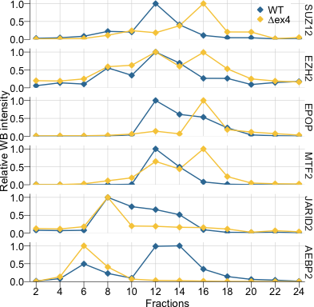

```r
ggplot(data = fractionation_wb2) +
  aes(x = Fraction, y = Intensity, color = line) +
  facet_grid(rows = vars(Protein) ) +
  geom_line(linewidth = 0.25, linetype = 'solid') +
  geom_point(aes(fill = line), size = 0.5, shape = 23, stroke = 0.5) +
  scale_x_continuous(breaks = seq(2, 24, 2), limits = c(2, 24), expand = expansion(add = 0.5, mult = 0) ) +
  scale_y_continuous(breaks = c(0, 0.5, 1), expand = expansion(add = c(0, 0.1), mult = 0) ) +
  scale_color_manual(values = c('WT' = "#377AA3", '∆ex4' = "#F7CB48") ) +
  scale_fill_manual(values = c('WT' = "#377AA3", '∆ex4' = "#F7CB48") ) +
  coord_cartesian(ylim = c(0, 1)) +
  labs(x = 'Fractions', y = 'Relative WB intensity') +
  gradients_theme -> p_wt_dex_frac_wb2
p_wt_dex_frac_wb2
```

Save to pdf.

```r
ggsave(filename = "FigS3E_Gradient_WT_Dex4_Line.pdf", path = pdf_dir_fig3,
       plot = p_wt_dex_frac_wb2, device = cairo_pdf, units = 'cm',
       width = 5.15, height = 5)
```

Combine both biological replicates into one plot in case someone wants it.

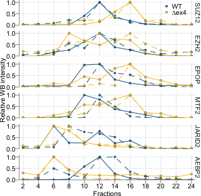

```r
rbind(fractionation_wb, fractionation_wb2) |>
  ggplot() +
    aes(x = Fraction, y = Intensity, group = interaction(line,BiolRep) ) +
    facet_grid(rows = vars(Protein) ) +
    geom_path(aes(color = line, linetype = BiolRep), linewidth = 0.25) +
    geom_point(aes(fill = line, shape = factor(BiolRep)), colour = 'black', size = 0.65, stroke = 0.1) +
    scale_linetype_binned( c("1", "2") ) +
    scale_shape_manual(values = c("1" = 21, "2" = 23)) +
    scale_x_continuous(breaks = seq(2, 24, 2), limits = c(2, 24), expand = expansion(add = 0.5, mult = 0) ) +
    scale_y_continuous(breaks = c(0, 0.5, 1), expand = expansion(add = c(0, 0.1), mult = 0) ) +
    scale_color_manual(values = c('WT' = "#377AA3", '∆ex4' = "#F7CB48") ) +
    scale_fill_manual(values = c('WT' = "#377AA3", '∆ex4' = "#F7CB48") ) +
    coord_cartesian(ylim = c(0, 1)) +
    guides(shape = "none", linetype = 'none', fill = guide_legend(override.aes = list(shape = 22))) +
    labs(x = 'Fractions', y = 'Relative WB intensity') +
    gradients_theme -> p_wt_dex_frac_wb_both_reps
p_wt_dex_frac_wb_both_reps
```

Save to pdf the combined biological replicate plot

```r
ggsave(filename = "Combined_Reps_Gradient_WT_Dex4_Line.pdf", path = pdf_dir_fig3,
       plot = p_wt_dex_frac_wb_both_reps, device = cairo_pdf, units = 'cm',
       width = 5.15, height = 5)
```

End of figure 3 and S3 analysis.

## References

Chammas, Paul, Ivano Mocavini, and Luciano Di Croce. 2020. “Engaging chromatin: PRC2 structure meets function.” *British Journal of Cancer* 122 (3): 315–28. https://doi.org/10.1038/s41416-019-0615-2.

Chen, Siming, Lianying Jiao, Xiuli Liu, Xin Yang, and Xin Liu. 2020. “A Dimeric Structural Scaffold for PRC2-PCL Targeting to CpG Island Chromatin.” *Molecular Cell* 77 (6): 1265–1278.e7. https://doi.org/10.1016/j.molcel.2019.12.019.

Mirdita, Milot, Konstantin Schütze, Yoshitaka Moriwaki, Lim Heo, Sergey Ovchinnikov, and Martin Steinegger. 2022. “ColabFold: making protein folding accessible to all.” *Nature Methods* 19 (6): 679–82. https://doi.org/10.1038/s41592-022-01488-1.

Youmans, Daniel T., Anne R. Gooding, Robin D. Dowell, and Thomas R. Cech. 2021. “Competition between PRC2.1 and 2.2 subcomplexes regulates PRC2 chromatin occupancy in human stem cells.” *Molecular Cell*. https://doi.org/10.1016/j.molcel.2020.11.044.